# Simulation of enzyme kinetics data

```r
library(here)
library(fs)
library(readxl)
library(writexl)
library(tidyverse)
library(magrittr)
library(broom)
library(gridExtra)
library(ggpmisc)
```

### Set the experimental parameters

All enzyme-related parameters are put into a single dataframe.

```r
# Import the parameters for the simulations
rxn_params <- read_xlsx(here("data", "reaction_parameters.xlsx"))

# Reaction duration in minutes
time <- c(.17, .33, .5, .66, .83, 1)

# Substrates
rxn_substr <- unique(rxn_params$rxn_substrate)

# Type of inhibition
inh_type <- unique(rxn_params$inhibition_actual)[-1]

# Substrate concentration in mM
substr_conc <- c(0,10,20,40,80,160)

# Required params to calculate gradients
cuv_vol <- 0.003 # volume of cuvette (l)
eps <- 6220 # extinction coefficient
enz_vol <- 0.1 # volume of enzyme added (ml)
```

### Add students and set up parameters for each student

```r
# Import the list with student names
students <- read_xlsx(here("data", "student_names_real.xlsx"))

# Randomly assign substrate and inhibition type to each student
students_rxn_conditions <- students %>%
  mutate(student_id = paste(toupper(student_no), toupper(first_name), sep = "_"),
         rxn_substrate = sample(rxn_substr, nrow(students), replace = TRUE),
         inhibition_actual = sample(inh_type, nrow(students), replace = TRUE)) %>%
  uncount(., 2, .id = "id") %>%
  mutate(inhibition_actual = ifelse(id == 2, "no_inhibition", inhibition_actual)) %>%
  select(-student_no, -first_name, -surname, -id)
```

```r
# Assemble all basic parameters with student information
students_rxn_params <- students_rxn_conditions %>%
  left_join(., rxn_params, by = c("rxn_substrate", "inhibition_actual")) %>%
  mutate(substrate_conc = list(substr_conc)) # Add substrate concentrations as list-column

students_rxn_params
```

| student_id | rxn_substrate | inhibition_actual | Kcat | Km | Vmax | enzyme_conc | substrate_conc |
| --- | --- | --- | --- | --- | --- | --- | --- |
| U01_FIRSTNAME1 | hexanol | uncompetitive | 16 | 5.70 | 0.960 | 0.025 |  |
| U01_FIRSTNAME1 | hexanol | no_inhibition | 16 | 9.50 | 1.600 | 0.025 |  |
| U02_FIRSTNAME2 | propanol | uncompetitive | 120 | 16.20 | 2.880 | 0.010 |  |
| U02_FIRSTNAME2 | propanol | no_inhibition | 120 | 27.00 | 4.800 | 0.010 |  |
| U03_FIRSTNAME3 | hexanol | uncompetitive | 16 | 5.70 | 0.960 | 0.025 |  |
| U03_FIRSTNAME3 | hexanol | no_inhibition | 16 | 9.50 | 1.600 | 0.025 |  |
| U04_FIRSTNAME4 | hexanol | uncompetitive | 16 | 5.70 | 0.960 | 0.025 |  |
| U04_FIRSTNAME4 | hexanol | no_inhibition | 16 | 9.50 | 1.600 | 0.025 |  |
| U05_FIRSTNAME5 | pentanol | competitive | 29 | 55.13 | 2.320 | 0.020 |  |
| U05_FIRSTNAME5 | pentanol | no_inhibition | 29 | 37.00 | 2.320 | 0.020 |  |

[output cut: 30 more lines]

```r
# Fixing Shamus' gremlins
#students_rxn_params <- read_tsv(here("data", "students_rxn_params.txt")) %>% mutate(substrate_conc = list(substr_conc))
```

### Functions to calculate reaction rates, gradients and fitting of the nls model to MM curve

```r
# Function to calculate reaction rate V, with some jitter added to substrate concentration
calculateV <- function(Vmax, Km, substrate_conc){
  V = Vmax  *  ifelse(substrate_conc > 0, jitter(substrate_conc), substrate_conc)  /  (Km    +    ifelse(substrate_conc > 0, jitter(substrate_conc), substrate_conc))
  return(V)
}

# Function to calculate gradients for each reaction rate, , with some jitter added to volume of the enzyme
calculateGradient <- function(Vmax, Km, substrate_conc){
  V = Vmax  *  ifelse(substrate_conc > 0, jitter(substrate_conc), substrate_conc)  /  (Km    +    ifelse(substrate_conc > 0, jitter(substrate_conc), substrate_conc))
  gradient = V * jitter(enz_vol) / 1000000 / cuv_vol * eps
  return(gradient)
}
?jitter
# Function to fit non-linear model to MM curve and estimate Km and Vmax
# Because different parameters require different levels of nesting, I calculate rxn_rate and gradient separately from Km and Vmax and join them later
# The nls function doesn't work unless you round the rxn_rate values (floating point error?)
estimateKmVmax <- function(df){
  nls(rxn_rate ~ estimated_Vmax * substrate_conc / (estimated_Km + substrate_conc), data = df, start = list(estimated_Km = 5, estimated_Vmax = 0.05)) %>%
    tidy() %>%
    select(parameter = term, estimate) %>%
    mutate(estimate = round(estimate, digits = 2)) %>%
    pivot_wider(names_from = parameter, values_from = estimate)
}
```

```r
# No jitter - fixing Shamus' gremlins
# Function to calculate reaction rate V
calculateV <- function(Vmax, Km, substrate_conc){
  V = Vmax  * substrate_conc / (Km + substrate_conc)
  return(V)
}

# Function to calculate gradients for each reaction rate, , with some jitter added to volume of the enzyme
calculateGradient <- function(Vmax, Km, substrate_conc){
  V = Vmax  *  substrate_conc / (Km + substrate_conc)
  gradient = V * enz_vol / 1000000 / cuv_vol * eps
  return(gradient)
}

# Function to fit non-linear model to MM curve and estimate Km and Vmax
# Because different parameters require different levels of nesting, I calculate rxn_rate and gradient separately from Km and Vmax and join them later
estimateKmVmax <- function(df){
  nls(rxn_rate ~ estimated_Vmax * substrate_conc / (estimated_Km + substrate_conc), data = df, start = list(estimated_Km = 5, estimated_Vmax = 0.05)) %>%
    tidy() %>%
    select(parameter = term, estimate) %>%
    mutate(estimate = round(estimate, digits = 2)) %>%
    pivot_wider(names_from = parameter, values_from = estimate)
}
```

### Estimate Km and Vmax from the data

I shape it into a table suitable for the final print.

```r
# Estimate the Km and Vmax from rxn_rate and substrate_conc
# The nls function doesn't work unless you round the rxn_rate values!!! (floating point error?)
estimated_Km_Vmax <- students_rxn_params %>%
  mutate(rxn_rate = pmap(select(., Vmax, Km, substrate_conc), calculateV)) %>%  # Calculation of V for different substrate concentrations
  unnest(c(rxn_rate, substrate_conc)) %>%
  mutate(rxn_rate = round(rxn_rate, digits = 2)) %>%
  group_by(student_id, rxn_substrate, inhibition_actual) %>%
  nest() %>%
  mutate(estimated_params = map(data, estimateKmVmax)) %>%
  select(-data) %>%
  mutate(estimated_params = bind_cols(inhibition_type = inhibition_actual, estimated_params)) %>%
  unnest(estimated_params) %>%
  ungroup() %>%
  select(-inhibition_actual) %>%
  group_by(student_id, rxn_substrate) %>%
  nest() %>%
  summarise(estimated_params = list(data)) %>% # Is this necessary?
  unnest(estimated_params)
estimated_Km_Vmax
```

| student_id | rxn_substrate | estimated_params |
| --- | --- | --- |
| U01_FIRSTNAME1 | hexanol |  |
| U02_FIRSTNAME2 | propanol |  |
| U03_FIRSTNAME3 | hexanol |  |
| U04_FIRSTNAME4 | hexanol |  |
| U05_FIRSTNAME5 | pentanol |  |
| U06_FIRSTNAME6 | ethanol |  |
| U07_FIRSTNAME7 | ethanol |  |
| U08_FIRSTNAME8 | pentanol |  |
| U09_FIRSTNAME9 | butanol |  |
| U10_FIRSTNAME10 | butanol |  |

[output cut: 10 more lines]

### Create folder using current system time

```r
# Time stamp
now <- format(Sys.time(), "%d-%b-%Y %H.%M")

#directory name
outputfolder <- paste("output/", now, sep = "")

#create directory
dir.create(here(outputfolder))
```

### Create data for each student and save to disk

```r
# Function to generate data files for each student
generateAbsVsTimeData <- function(student_id, df) {
  df %>%
    mutate(student_id = student_id,
           substrate_conc_char = paste(substrate_conc, "mM", sep = "_")) %>%
    select(-c(inhibition_actual, substrate_conc)) %>%
    pivot_wider(names_from = substrate_conc_char, values_from = absorbance) %>%
    select(student_id, rxn_substrate, rxn_condition, rxn_time, everything()) %>%
    write_xlsx(here(outputfolder, paste(student_id, "data_new.xlsx", sep = "_")))
}

# Create the student data
students_rxn_params %>%
  mutate(gradient = pmap(select(., Vmax, Km, substrate_conc), calculateGradient),
         rxn_time = list(time)) %>%  # Calculate of gradients for different reaction rates
  unnest(c(rxn_time)) %>%
  unnest(c(substrate_conc, gradient)) %>% # Expand the dataframe to have multiple time points for each gradients
  mutate(absorbance = round(gradient * rxn_time, digits = 3),
         rxn_condition = case_when(
           inhibition_actual == "no_inhibition" ~ "without_inhibitor",
           TRUE ~ "with_inhibitor")) %>%
  relocate(rxn_condition, .after = inhibition_actual) %>%
  select(student_id, rxn_substrate, inhibition_actual, rxn_condition, substrate_conc, rxn_time, absorbance) %>%
  group_by(student_id) %>%
  nest() %$%
  map2(student_id, data, generateAbsVsTimeData)
```

```
[[1]]
[1] "C:\\Users\\raymo\\Documents\\UNIVERSITY\\Year 3\\Final Year Project\\maudr\\output\\24-May-2022 21.25\\U01_FIRSTNAME1_data_new.xlsx"

[[2]]
[1] "C:\\Users\\raymo\\Documents\\UNIVERSITY\\Year 3\\Final Year Project\\maudr\\output\\24-May-2022 21.25\\U02_FIRSTNAME2_data_new.xlsx"

[[3]]
[1] "C:\\Users\\raymo\\Documents\\UNIVERSITY\\Year 3\\Final Year Project\\maudr\\output\\24-May-2022 21.25\\U03_FIRSTNAME3_data_new.xlsx"

[[4]]
[1] "C:\\Users\\raymo\\Documents\\UNIVERSITY\\Year 3\\Final Year Project\\maudr\\output\\24-May-2022 21.25\\U04_FIRSTNAME4_data_new.xlsx"

[[5]]
[1] "C:\\Users\\raymo\\Documents\\UNIVERSITY\\Year 3\\Final Year Project\\maudr\\output\\24-May-2022 21.25\\U05_FIRSTNAME5_data_new.xlsx"

[[6]]
[1] "C:\\Users\\raymo\\Documents\\UNIVERSITY\\Year 3\\Final Year Project\\maudr\\output\\24-May-2022 21.25\\U06_FIRSTNAME6_data_new.xlsx"

[[7]]
[1] "C:\\Users\\raymo\\Documents\\UNIVERSITY\\Year 3\\Final Year Project\\maudr\\output\\24-May-2022 21.25\\U07_FIRSTNAME7_data_new.xlsx"

[[8]]
[1] "C:\\Users\\raymo\\Documents\\UNIVERSITY\\Year 3\\Final Year Project\\maudr\\output\\24-May-2022 21.25\\U08_FIRSTNAME8_data_new.xlsx"

[[9]]
[1] "C:\\Users\\raymo\\Documents\\UNIVERSITY\\Year 3\\Final Year Project\\maudr\\output\\24-May-2022 21.25\\U09_FIRSTNAME9_data_new.xlsx"

[[10]]
[1] "C:\\Users\\raymo\\Documents\\UNIVERSITY\\Year 3\\Final Year Project\\maudr\\output\\24-May-2022 21.25\\U10_FIRSTNAME10_data_new.xlsx"

[[11]]
[1] "C:\\Users\\raymo\\Documents\\UNIVERSITY\\Year 3\\Final Year Project\\maudr\\output\\24-May-2022 21.25\\U11_FIRSTNAME11_data_new.xlsx"

[[12]]
[1] "C:\\Users\\raymo\\Documents\\UNIVERSITY\\Year 3\\Final Year Project\\maudr\\output\\24-May-2022 21.25\\U12_FIRSTNAME12_data_new.xlsx"

[[13]]
[1] "C:\\Users\\raymo\\Documents\\UNIVERSITY\\Year 3\\Final Year Project\\maudr\\output\\24-May-2022 21.25\\U13_FIRSTNAME13_data_new.xlsx"

[[14]]
[1] "C:\\Users\\raymo\\Documents\\UNIVERSITY\\Year 3\\Final Year Project\\maudr\\output\\24-May-2022 21.25\\U14_FIRSTNAME14_data_new.xlsx"

[[15]]
[1] "C:\\Users\\raymo\\Documents\\UNIVERSITY\\Year 3\\Final Year Project\\maudr\\output\\24-May-2022 21.25\\U15_FIRSTNAME15_data_new.xlsx"

[[16]]
[1] "C:\\Users\\raymo\\Documents\\UNIVERSITY\\Year 3\\Final Year Project\\maudr\\output\\24-May-2022 21.25\\U16_FIRSTNAME16_data_new.xlsx"

[[17]]
[1] "C:\\Users\\raymo\\Documents\\UNIVERSITY\\Year 3\\Final Year Project\\maudr\\output\\24-May-2022 21.25\\U17_FIRSTNAME17_data_new.xlsx"

[[18]]
[1] "C:\\Users\\raymo\\Documents\\UNIVERSITY\\Year 3\\Final Year Project\\maudr\\output\\24-May-2022 21.25\\U18_FIRSTNAME18_data_new.xlsx"

[[19]]
[1] "C:\\Users\\raymo\\Documents\\UNIVERSITY\\Year 3\\Final Year Project\\maudr\\output\\24-May-2022 21.25\\U19_FIRSTNAME19_data_new.xlsx"

[[20]]
[1] "C:\\Users\\raymo\\Documents\\UNIVERSITY\\Year 3\\Final Year Project\\maudr\\output\\24-May-2022 21.25\\U20_FIRSTNAME20_data_new.xlsx"
```

## Prepare answer files

I generate the answers from the students’ data files simulated data. I am **not** re-loading students’ answer files to generate the answers.

### Functions to generate plots

Note that for the Lineweaver-Burke plot the x axis limits need to be dynamically calculated to include the x axis intercept for the non-inhibited data, but I don’t know how to do it. Currently the limit is hard-coded to -0.05 but it won’t be sufficient in all cases.

```r
# Absorbance vs time plot
plotAbsVsTime <- function(df){
  df %>%
  mutate(gradient = pmap(select(., Vmax, Km, substrate_conc), calculateGradient), # Calculate of gradients for different substrate concentrations
         rxn_time = list(time)) %>%
  unnest(c(rxn_time)) %>%
  unnest(c(substrate_conc, gradient)) %>% # Expand the dataframe for reaction rate and concentration
  mutate(absorbance = round(gradient * rxn_time, digits = 3), # Calculate absorbance
         substrate_conc = fct_relevel(as.character(substrate_conc), levels = c("0", "10", "20", "40", "80", "160"))) %>%
  ggplot() + aes(x = rxn_time, y = absorbance, colour = substrate_conc) + geom_point() + geom_smooth(method = "lm", se = FALSE) + facet_wrap(~inhibition_actual) +
    labs(x = "Reaction time (min)",
         y = "Absorbance (AU)",
         title = "Absorbance vs reaction time plot",
         colour = "Substrate concentration (mM)") +
    theme_minimal() +
    theme(legend.position = "bottom")
}

# Michaelis-Menten plot
plotMM <- function(df) {
  df %>%
  mutate(rxn_rate = pmap(select(., Vmax, Km, substrate_conc), calculateV)) %>%  # Calculate reaction rates
  unnest(c(substrate_conc, rxn_rate)) %>% # Expand the dataframe for reaction rate and concentration
  ggplot() + aes(x = substrate_conc, y = rxn_rate, colour = inhibition_actual) + geom_point() +
    labs(x = "Substrate concentration (mM)",
         y = "Reaction rate (∆abs/min)",
         title = "Michaelis-Menten plot",
         colour = "Type of inhibition") +
    theme_minimal() +
    theme(legend.position = "bottom")
}

# Lineweaver-Burke plot
plotLB <- function(df) {
  df %>%
  mutate(rxn_rate = pmap(select(., Vmax, Km, substrate_conc), calculateV)) %>%  # Calculate of gradients for different reaction rates
  unnest(c(substrate_conc, rxn_rate)) %>% # Expand the dataframe for reaction rate and concentration
  filter(substrate_conc != 0) %>%
  mutate(substrate_conc_reciprocal = 1/substrate_conc,
         rxn_rate_reciprocal = 1/rxn_rate) %>%
  ggplot() + aes(x = substrate_conc_reciprocal, y = rxn_rate_reciprocal, colour = inhibition_actual) + geom_point() + expand_limits(x = -0.05) + geom_smooth(method = "lm", se = FALSE, fullrange = TRUE) +
    labs(x = "Reciprocal substrate concentration (mM)",
         y = "Reciprocal reaction rate",
         title = "Lineweaver-Burke plot",
         colour = "Type of inhibition") +
    theme_minimal() +
    theme(legend.position = "bottom") +
    stat_poly_eq(aes(label =  paste(after_stat(eq.label), after_stat(rr.label), sep = "*\", \"*")))
}
```

### Generate all the plots

…and add the table with estimated Km and Vmax for the final print

```r
students_answers_data <- students_rxn_params %>%
  left_join(., estimated_Km_Vmax, by = c("student_id", "rxn_substrate")) %>%
  mutate(inhibition_actual = fct_relevel(inhibition_actual, "no_inhibition", after = 0L)) %>%
  group_by(student_id) %>%
  nest() %>%
  mutate(abs_vs_time_plot = map(data, plotAbsVsTime),
         mm_plot = map(data, plotMM),
         lb_plot = map(data, plotLB)) %>%
  unnest(data) %>%
  select(student_id, rxn_substrate, inhibition_actual, abs_vs_time_plot, mm_plot, lb_plot, estimated_params) %>%
  filter(inhibition_actual != "no_inhibition")
```

[output not shown]

### Combine all the elements and print the answer file for each student

Answers for each students are saved on a single page PDF and then combined into a multi-page document for ease of printing.

[output not shown]

[output cut: 1185 more lines]

[output not shown]

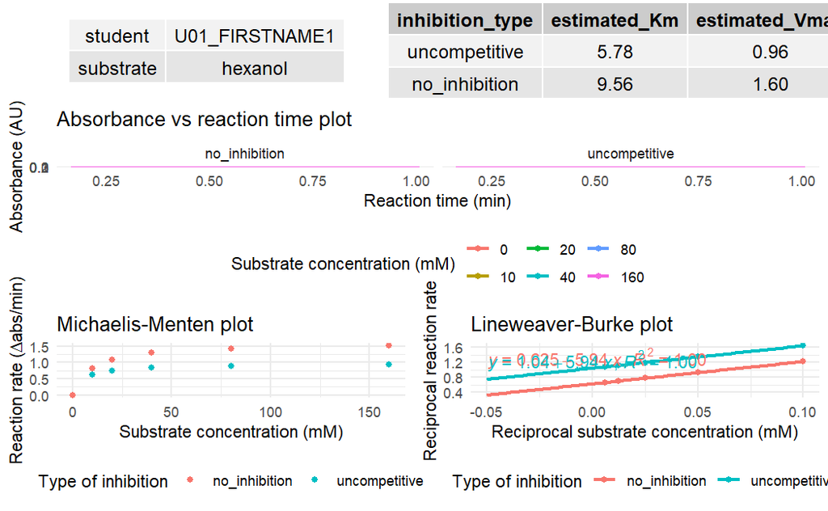

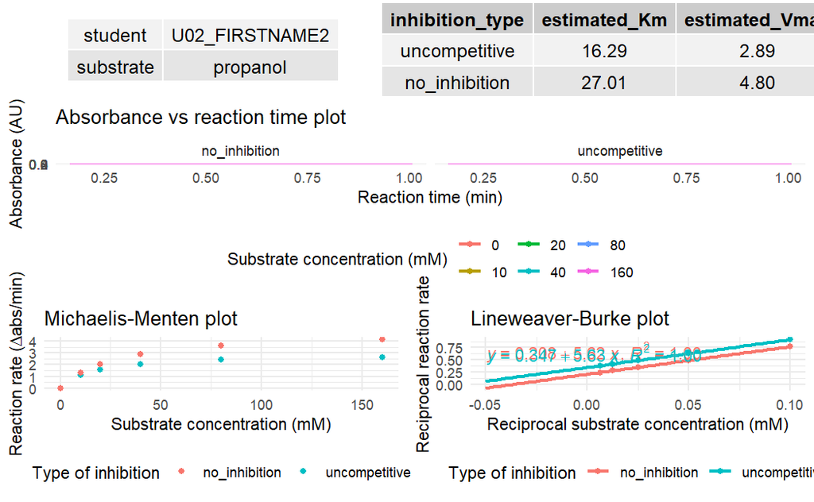

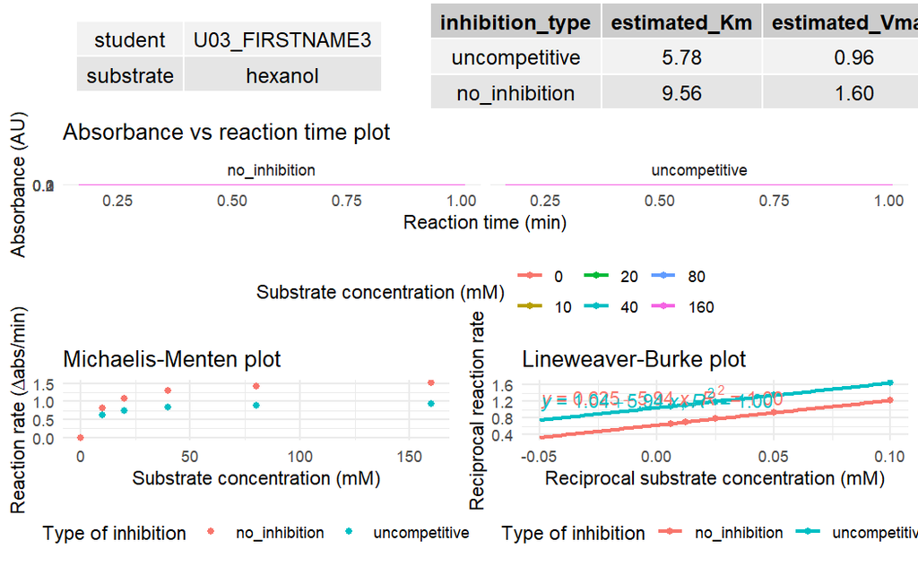

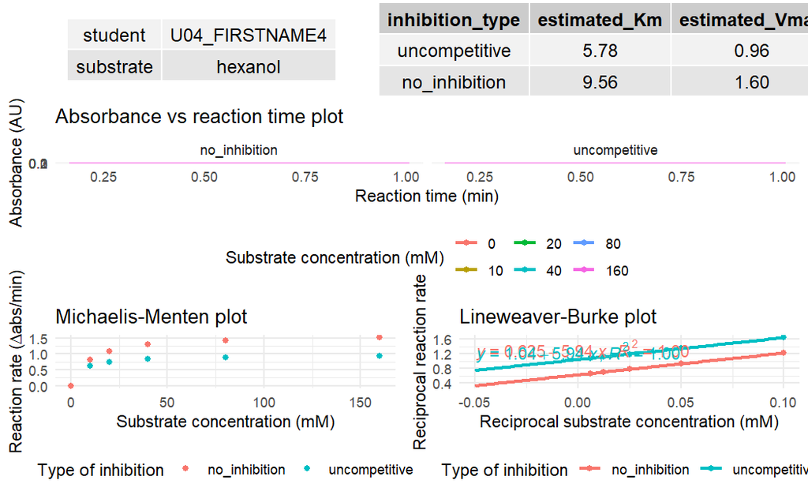

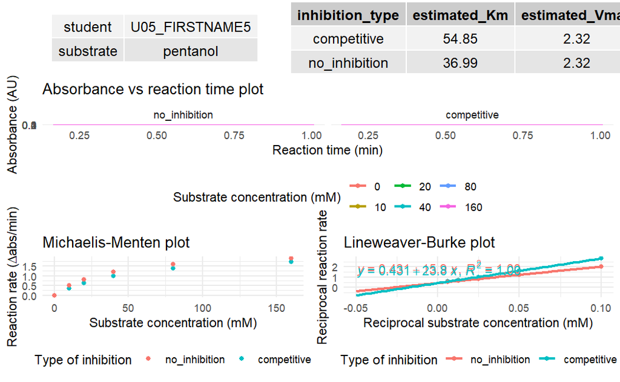

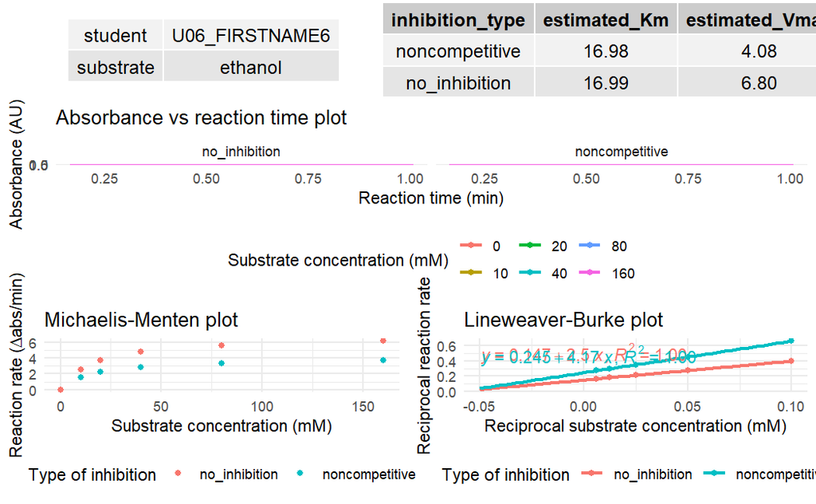

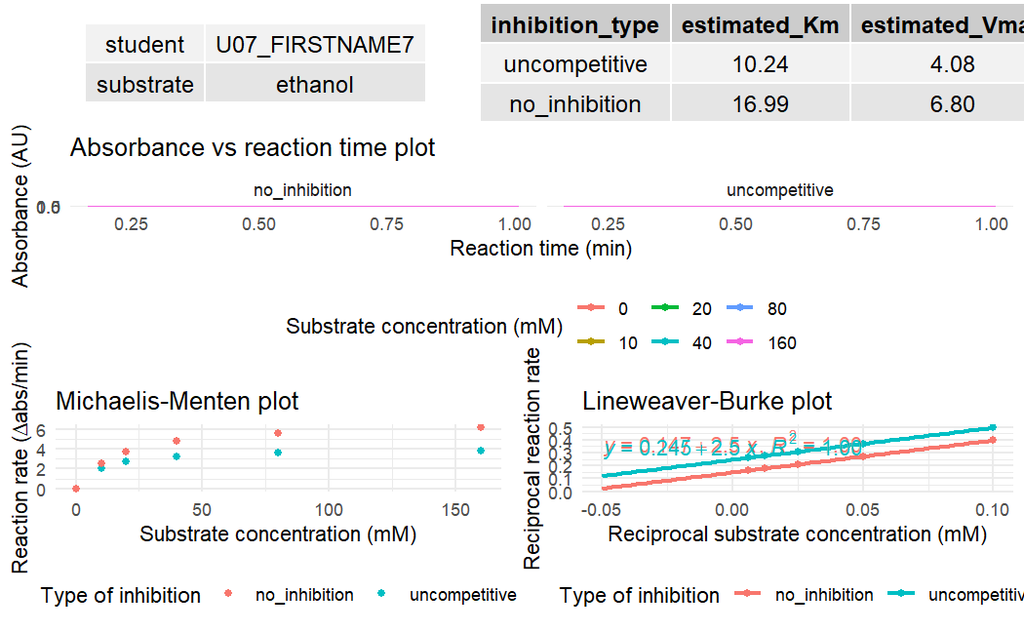

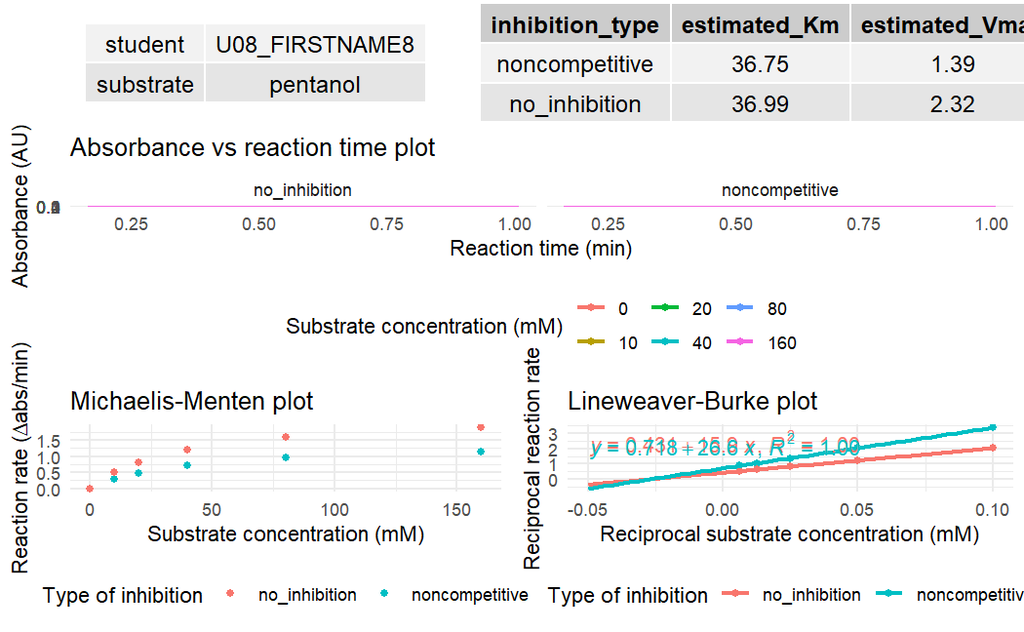

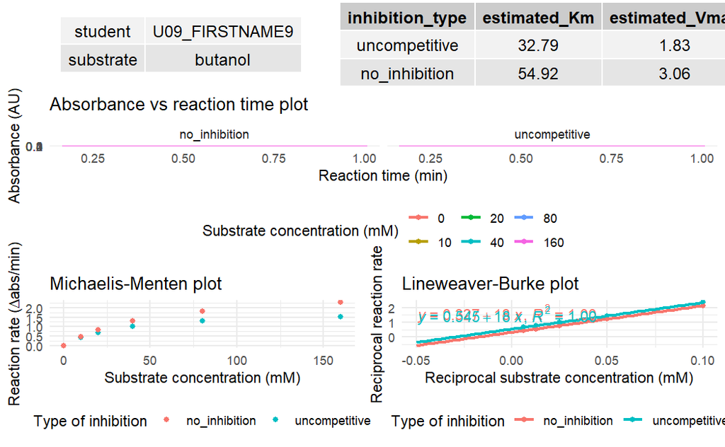

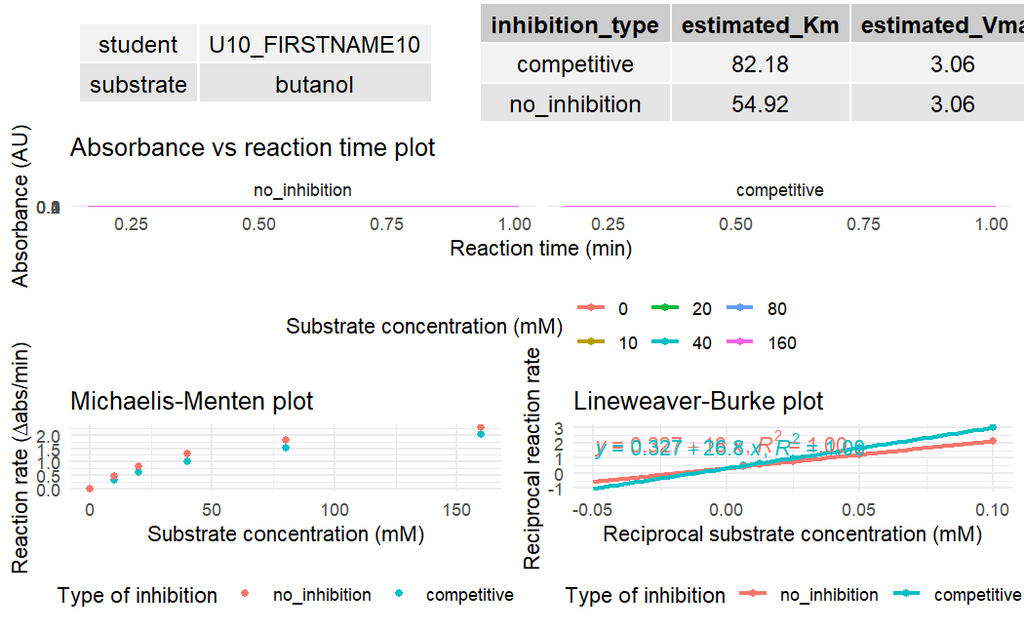

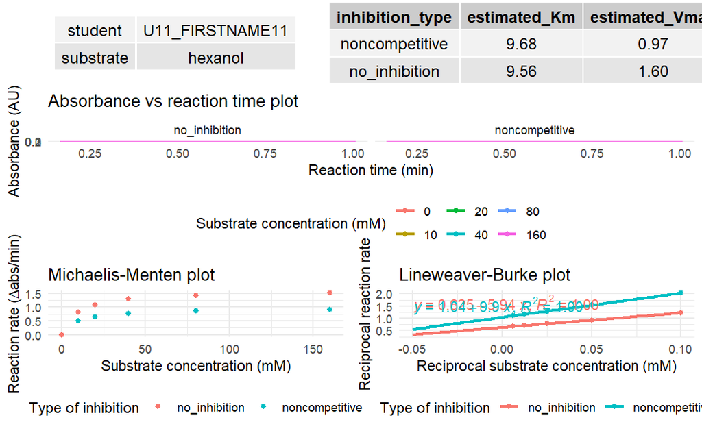

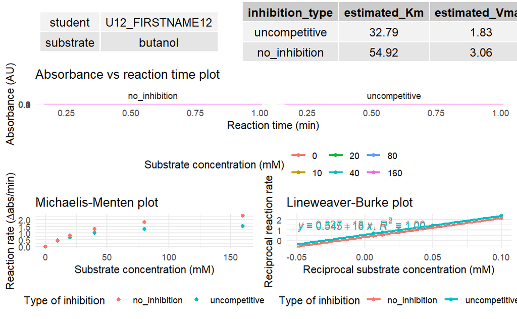

[8 more figures not shown]

```r
createAnswerPDF <- function(student_id, rxn_substrate, inhibition_actual, abs_vs_time_plot, mm_plot, lb_plot, estimated_params){
  table1 <- tableGrob(tibble("info" = c("student", "substrate"), " " = c(student_id, rxn_substrate)), rows = NULL, cols = NULL)
  table2 <- tableGrob(unnest(estimated_params), rows = NULL)
  layout <- rbind(c(1,2), c(3,3), c(3,3), c(4,5), c(4,5))
  answers <- grid.arrange(table1, table2, abs_vs_time_plot, mm_plot, lb_plot, layout_matrix = layout)
  return(answers)
}

ggsave(plot = marrangeGrob(pmap(students_answers_data, createAnswerPDF), nrow=1, ncol=1), here(outputfolder, "SIB2004_answers_all_students.pdf"), width = 210, height = 297, units = "mm", dpi = "retina")
```

[output not shown]

[output cut: 1185 more lines]

[output not shown]

```
[[1]]
[1] "C:/Users/raymo/Documents/UNIVERSITY/Year 3/Final Year Project/maudr/output/24-May-2022 21.25/U01_FIRSTNAME1_answers_new.pdf"

[[2]]
[1] "C:/Users/raymo/Documents/UNIVERSITY/Year 3/Final Year Project/maudr/output/24-May-2022 21.25/U02_FIRSTNAME2_answers_new.pdf"

[[3]]
[1] "C:/Users/raymo/Documents/UNIVERSITY/Year 3/Final Year Project/maudr/output/24-May-2022 21.25/U03_FIRSTNAME3_answers_new.pdf"

[[4]]
[1] "C:/Users/raymo/Documents/UNIVERSITY/Year 3/Final Year Project/maudr/output/24-May-2022 21.25/U04_FIRSTNAME4_answers_new.pdf"

[[5]]
[1] "C:/Users/raymo/Documents/UNIVERSITY/Year 3/Final Year Project/maudr/output/24-May-2022 21.25/U05_FIRSTNAME5_answers_new.pdf"

[[6]]
[1] "C:/Users/raymo/Documents/UNIVERSITY/Year 3/Final Year Project/maudr/output/24-May-2022 21.25/U06_FIRSTNAME6_answers_new.pdf"

[[7]]
[1] "C:/Users/raymo/Documents/UNIVERSITY/Year 3/Final Year Project/maudr/output/24-May-2022 21.25/U07_FIRSTNAME7_answers_new.pdf"

[[8]]
[1] "C:/Users/raymo/Documents/UNIVERSITY/Year 3/Final Year Project/maudr/output/24-May-2022 21.25/U08_FIRSTNAME8_answers_new.pdf"

[[9]]
[1] "C:/Users/raymo/Documents/UNIVERSITY/Year 3/Final Year Project/maudr/output/24-May-2022 21.25/U09_FIRSTNAME9_answers_new.pdf"

[[10]]
[1] "C:/Users/raymo/Documents/UNIVERSITY/Year 3/Final Year Project/maudr/output/24-May-2022 21.25/U10_FIRSTNAME10_answers_new.pdf"

[[11]]
[1] "C:/Users/raymo/Documents/UNIVERSITY/Year 3/Final Year Project/maudr/output/24-May-2022 21.25/U11_FIRSTNAME11_answers_new.pdf"

[[12]]
[1] "C:/Users/raymo/Documents/UNIVERSITY/Year 3/Final Year Project/maudr/output/24-May-2022 21.25/U12_FIRSTNAME12_answers_new.pdf"

[[13]]
[1] "C:/Users/raymo/Documents/UNIVERSITY/Year 3/Final Year Project/maudr/output/24-May-2022 21.25/U13_FIRSTNAME13_answers_new.pdf"

[[14]]
[1] "C:/Users/raymo/Documents/UNIVERSITY/Year 3/Final Year Project/maudr/output/24-May-2022 21.25/U14_FIRSTNAME14_answers_new.pdf"

[[15]]
[1] "C:/Users/raymo/Documents/UNIVERSITY/Year 3/Final Year Project/maudr/output/24-May-2022 21.25/U15_FIRSTNAME15_answers_new.pdf"

[[16]]
[1] "C:/Users/raymo/Documents/UNIVERSITY/Year 3/Final Year Project/maudr/output/24-May-2022 21.25/U16_FIRSTNAME16_answers_new.pdf"

[[17]]
[1] "C:/Users/raymo/Documents/UNIVERSITY/Year 3/Final Year Project/maudr/output/24-May-2022 21.25/U17_FIRSTNAME17_answers_new.pdf"

[[18]]
[1] "C:/Users/raymo/Documents/UNIVERSITY/Year 3/Final Year Project/maudr/output/24-May-2022 21.25/U18_FIRSTNAME18_answers_new.pdf"

[[19]]
[1] "C:/Users/raymo/Documents/UNIVERSITY/Year 3/Final Year Project/maudr/output/24-May-2022 21.25/U19_FIRSTNAME19_answers_new.pdf"

[[20]]
[1] "C:/Users/raymo/Documents/UNIVERSITY/Year 3/Final Year Project/maudr/output/24-May-2022 21.25/U20_FIRSTNAME20_answers_new.pdf"
```

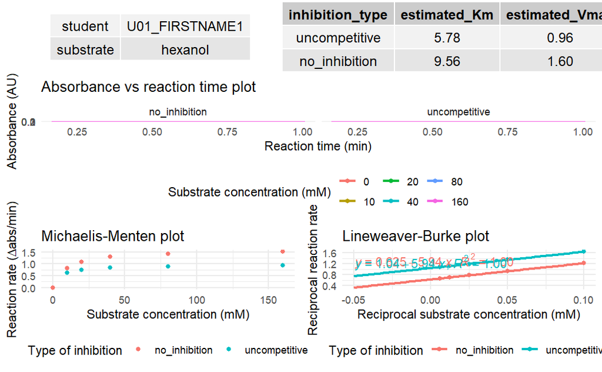

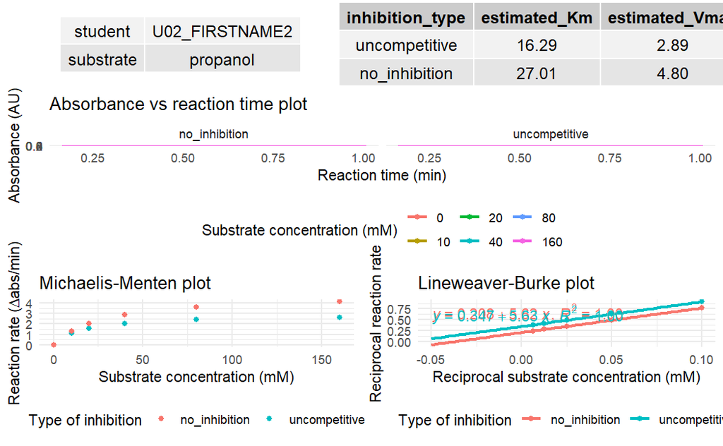

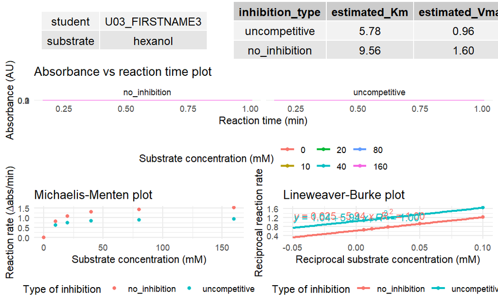

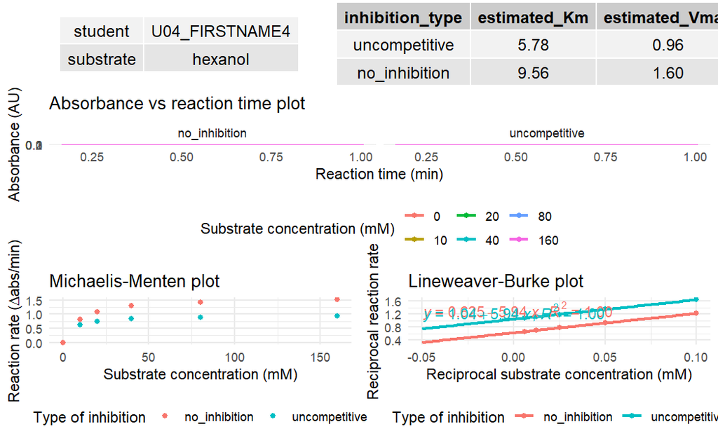

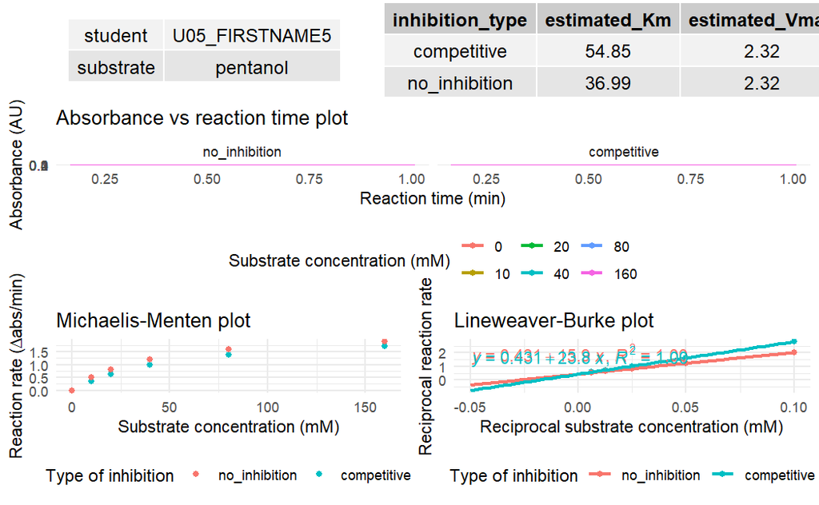

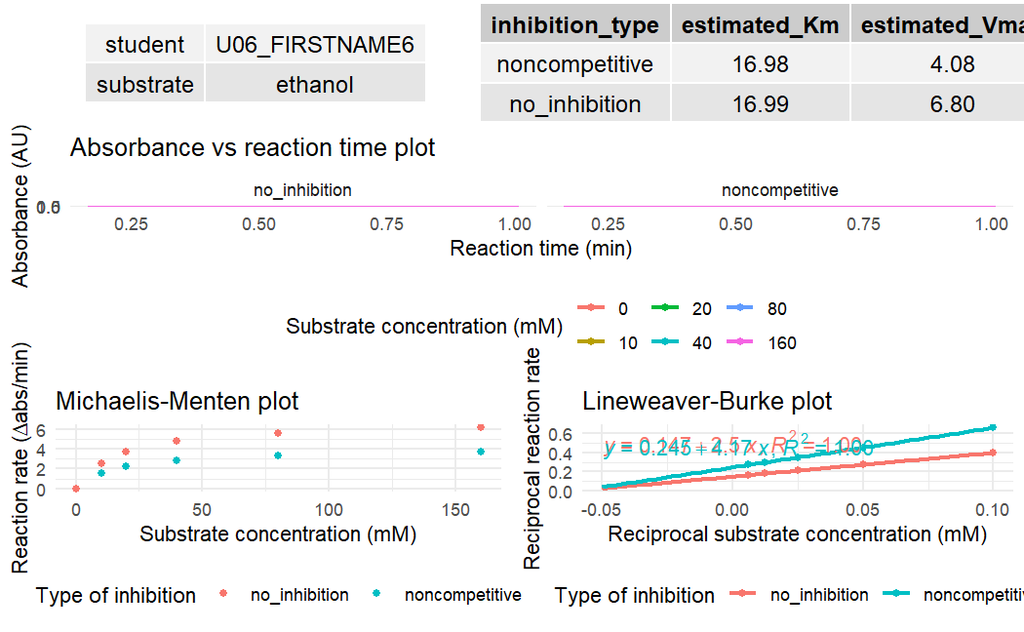

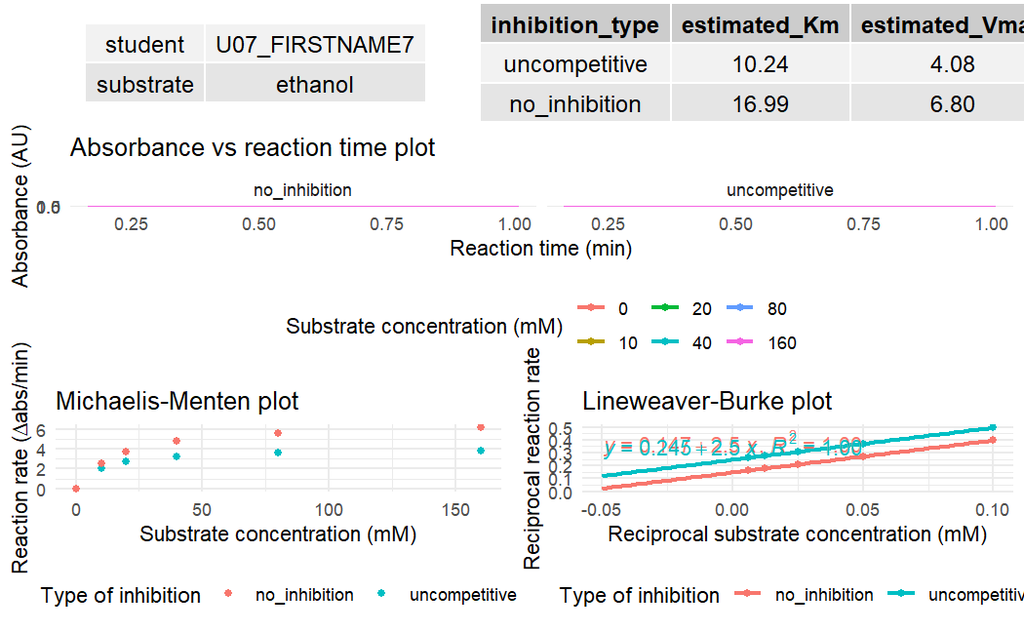

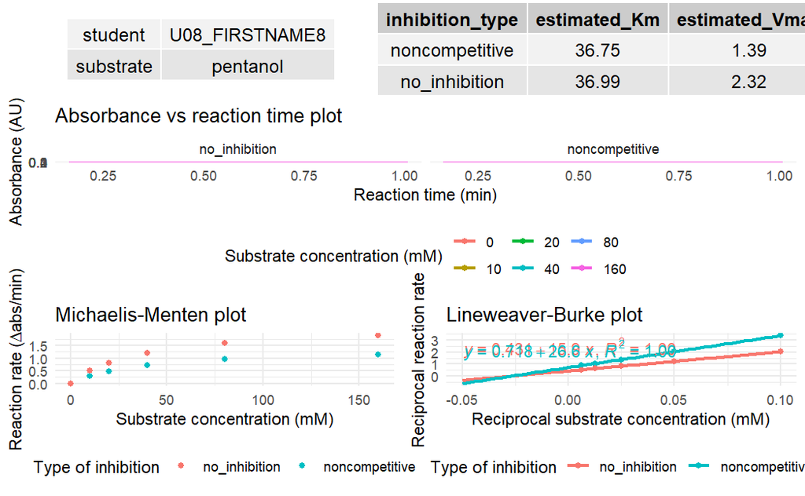

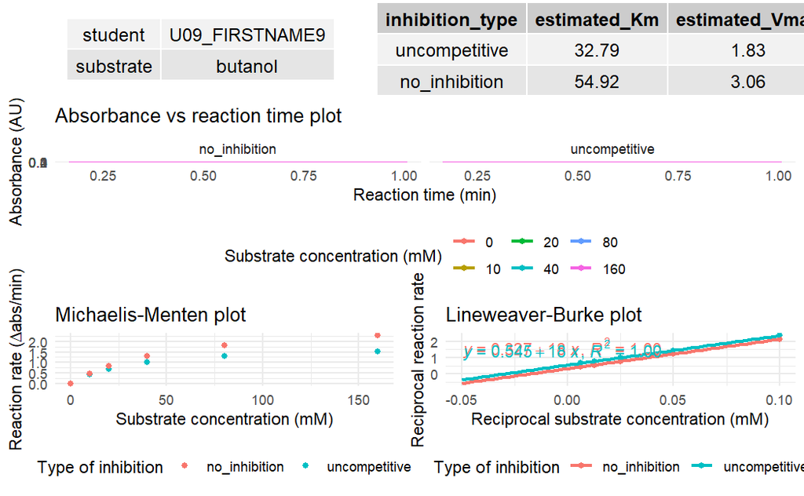

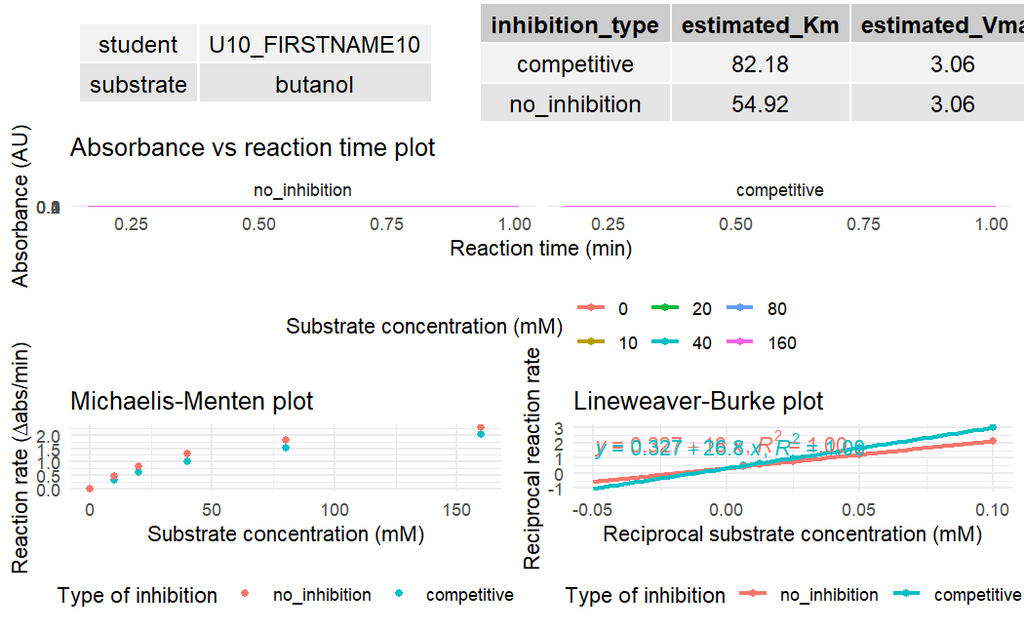

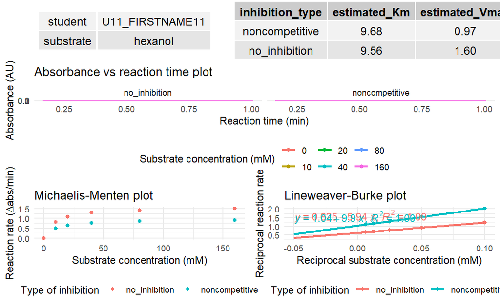

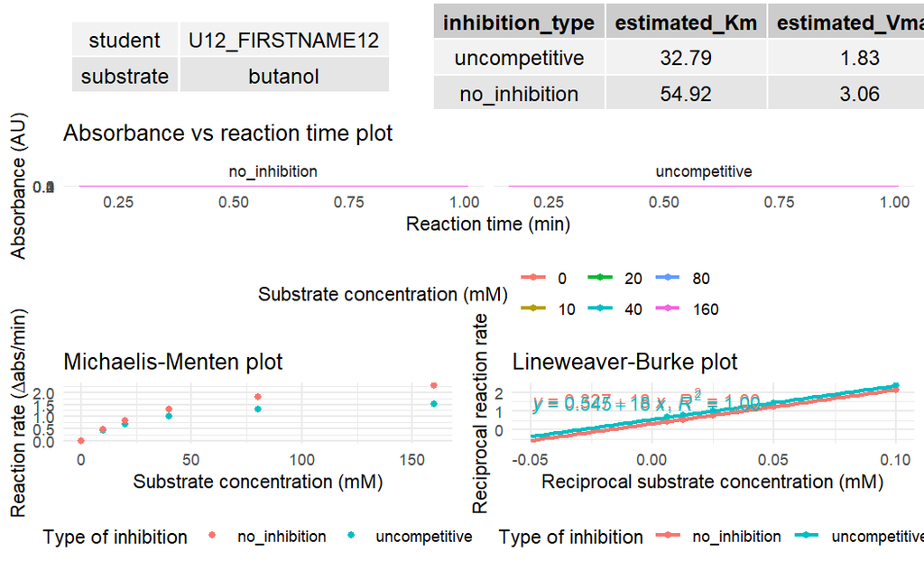

[8 more figures not shown]

```r
# Solution for separate files for each student
createAnswerPDF2 <- function(student_id, rxn_substrate, inhibition_actual, abs_vs_time_plot, mm_plot, lb_plot, estimated_params){
  table1 <- tableGrob(tibble("info" = c("student", "substrate"), " " = c(student_id, rxn_substrate)), rows = NULL, cols = NULL)
  table2 <- tableGrob(unnest(estimated_params), rows = NULL)
  layout <- rbind(c(1,2), c(3,3), c(3,3), c(4,5), c(4,5))
  answers <- grid.arrange(table1, table2, abs_vs_time_plot, mm_plot, lb_plot, layout_matrix = layout)
  ggsave(plot = answers, path = here(outputfolder), filename = paste0(student_id, "_answers_new.pdf"), units = "mm", width = 210, height = 297, dpi = "retina")
}

pmap(students_answers_data, createAnswerPDF2)
```